# Cognitive classification in HRS Core: Learning from HCAP

Rich Jones and Doug Tommet for HRS/HCAP Working Group

## Contents

- Review problem
- Review previous work
- Outline new work
- Results

## Problem/question/goal

- Improve Core cognitive classification (e.g., Langa-Weir) using information extracted from HRS/HCAP (possibly measurement and/or prediction models)
- End goal: Cognitive classification, and classification probabilities

## Previous work

Previously we exported the “Manly-Jones” algorithm to the Core using a single domain of general cognitive performance to define cognitive impairment, ADLs and IADLS to define functional impairment. We applied cutpoints to cognition and functional measures to match the prevalence of cognitive impairment and functional impairment in the 2016 HCAP sample.

We wanted to do better, and we wanted a probabilistic information at the individual level about the classification.

## New approach: profile mixture modeling

- PMM is a mixture-modeling approach that uses the joint pattern of multiple observed indicators to define latent profiles and estimate the probability that each person belongs to each profile.
- In this project, PMM is trained against known HRS/HCAP actuarial classifications, with cognitive indicators adjusted using fixed parameters from the robust norms group, and then applied to HRS Core as a probabilistic classification rule.

## PMM structure

[figure not shown]

Separate models are trained for the cognitive and functional indicators, and the informant reports (Jorm IQCODE). The results of these models are then combined to generate a final classification for each person (N=3496). Recall that the Jorm informant reports are available only for those without cognitive data.

`cg` is a latent class variable (a known class in the HRS/HCAP calibration sample, and an unknown class in the HRS Core application sample) that is predicted by a set of cognitive indicators (the nine indicators listed below) that are adjusted for sociodemographics using fixed parameters from the robust norms group. The classes correspond to normal cognition, MCI/CIND, and dementia.

`K` is a matrix of fixed regression coefficients used to adjust cognitive indicators for sociodemographics. These parameters are estimated in the robust norms sample and then loaded into the classification model. For the nine cognitive indicators and fifteen sociodemographic terms, this contributes $9 \times 15 = 135$ coefficients. This normative reference group fixed-parameter regression is equivalent to the approach used by Manly et al (2022) (i.e., regression adjustment of cognitive domains using the normative reference group).

Cognitive indicators include `vdori`, Orientation to time; `vdlfl1z`, Animal naming; `vdlfl2`, naming two items; `vdlfl3`, President & vice-president; `vdcount`, Count backwards from 20; `vdsevens`, Serial sevens; `vdwdimmz`, Immediate word recall; `vdwddelz`, Delayed word recall; `vdexf7z`, Number series.

## PMM structure (where we started)

[figure not shown]

We started with a model that include a latent general cognitive performance factor (GCP), but that model resulted in poor classification (*entropy* = 0.71, vs 0.83 for the model with cognitive indicators included separately), and after consideration, the use we had in mind did not require the parsimony of a general factor as long as it was only applied to core data (with the same cognitive indicators).

We also thought we could include the Jorm in this model, but the missing data pattern made that overly complicated. We address informant data (available only for those with no cognitive data) separately. We build a separate PMM for the informant data (a PMM model so we can have a probabilistic classification result), and then combine the results of the two PMMs using whichever is appropriate for the respondent.

*Entropy* is a measure of classification model confidence, based on posterior probabilities. A model with higher entropy has better separation between classes, while a model with lower entropy has worse separation (lower entropy). Entropy provides a summary measure of classification uncertainty based on posterior class probabilities, with higher values indicating sharper separation between classes. Because entropy is a deterministic function of model-based probabilities and lacks a sampling distribution, it should not be used as a formal criterion for model selection but rather as a descriptive indicator of classification quality. Values greater than 0.70 are considered usable, and with values greater than 0.80 is considered strong classification and reliable class assignment.

## How our approach differs from LDA and QDA

LDA and QDA (Linear and quadratic discriminant analysis, respectively) classify people from the joint distribution of multiple indicators, but they are usually framed for continuous Gaussian variables. In LDA, classes differ in their means, but they are assumed to share the same covariance matrix. In QDA, both the class means and the class-specific covariance matrices are allowed to differ. Our PMM is closer to a generative LDA/QDA family model than to a simple discriminative classifier, because it models the distribution of the indicators within class and then computes posterior class probabilities.

For the cognitive indicators, PMM handles the indicator means through fixed sociodemographic adjustment terms estimated in the robust norms group, plus class-specific location shifts in the classification model. That means expected performance is anchored to the normative reference group rather than re-estimated in the target sample. For the indicator variances and covariances, the current PMM is LDA-like: residual variability is constrained to be equal across classes. A QDA-like extension would allow those residual variance-covariance parameters to differ by class. PMM is also more flexible than classical LDA or QDA because several indicators are ordinal or discrete, so class separation is represented through latent-response means, thresholds, and shared residual structure rather than only through multivariate Gaussian means and variances on the observed score scale.

## How our approach differs from predictive modeling

Many predictive models are optimized to maximize classification accuracy in the sample at hand, even if that means learning direct associations of sociodemographics with class membership or relying on patterns that are difficult to transport or interpret. Our PMM is built for a different goal: it separates measurement from classification, anchors expected cognitive performance in a normative reference group, and then classifies people according to how their observed indicator pattern departs from that demographically adjusted expectation. In this sense the PMM approach is a measurement model rather than a prediction model.

## How our is similar to LDA, ML

- Unlike Manly et al (2022), there is no decision tree.
- The PMM takes as input cognitive indicators, functional and self-report (and informant) data, and outputs probabilities of class membership. LDA, machine learning classifiers would do the same.

## Covariate adjustment

[figure not shown]

How to handle covariate adjustment, in a way consistent with what we did in Manly et al (2022), requires new methodology for the PMM. In Manly et al (2022), we adjust observed (continuous) cognitive indicators for covariates in the robust norms group (panel a1). Then we include in future analyses using the target (overall) sample the residual of observed cognition and expected cognition given the regression models defined in the robust norms group (panels b3, c3, the *residual* approach).

Approximately equivalent approaches to handling expectations-given-covariates-in-robust-norms-group would be to use the robust norms group defined regression parameters as fixed parameters in the target sample (panels b1, c1, the *fixed parameter* approach) or to include computed expected scores for each person, each outcome variable (y) given covariates and regression parameters defined in the robust norms group, and use these as an *offset* (regress observed on expected with coefficient fixed at 1; panels b2, c2).

All three of these approaches will return equivalent relationships between an external variable (z; panels c1-c3) and the cognitive variable.

We chose the fixed regression parameter approach (b1, c1) rather than the residual approach, because both the residual approach and the offset approach do not translate well to the case where the outcomes (y’s) are categorical.

## Results

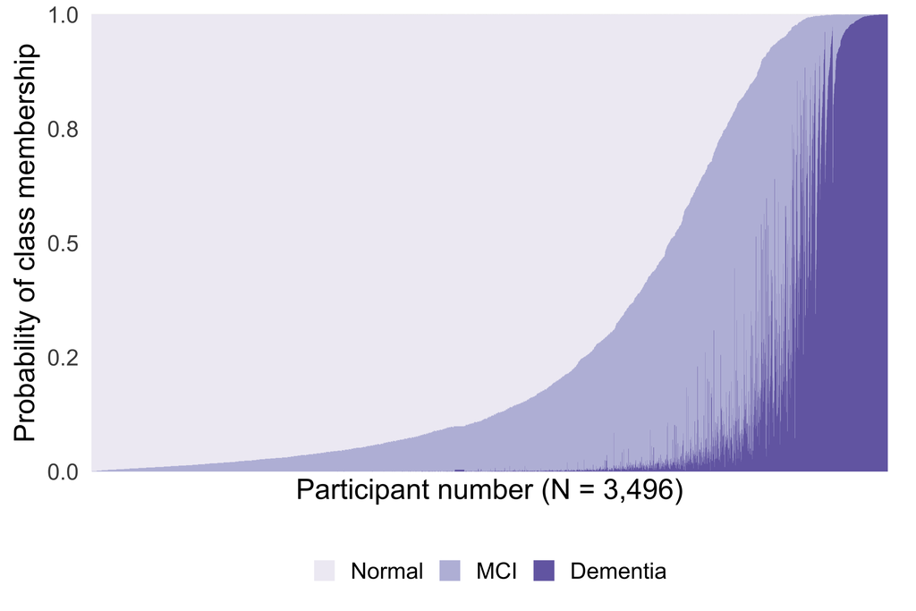

## Combined-Model Class Probabilities

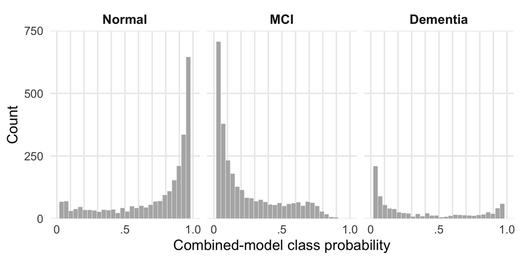

## Combined-Model Class Membership

According to most likely class membership. This is the value that would be used to generate a “predicted” class label for each participant in the HRS/HCAP sample.

| Class | N | Weighted % |
| --- | --- | --- |
| Normal | 2,557 | 76.7 |
| MCI | 568 | 13.6 |
| Dementia | 371 | 9.7 |

Note: N and weighted percentages are computed in the non-replicated HRS/HCAP sample (N = 3496). Weighted percentages use HCAP16WGTR. Combined-model probabilities and most likely class assignments use the cognition-model and Jorm-model combination rule.

By way of comparison, Manly et al. (2022) report that in the HCAP validation subsample, 68% of participants were classified as normal, 22% as MCI, and 10% as dementia according to the HRS/HCAP algorithm (weighted %, class assignments based on Bayesian Plausible Values for cognition scores). Langa-Weir classification of the HRS/HCAP sample classifies 75% as normal, 17% as MCI, and 8% as dementia (see PMM_Analysis_Report).

## Normal, MCI, Dementia (3-way) Agreement Matrix

Pairwise quadratic weighted kappa matrix using consensus-panel weights for consensus comparisons and HCAP weights otherwise

| Consensus sample | Consensus diagnosis | Algorithmic diagnosis | Langa-Weir | Combined model |
| --- | --- | --- | --- | --- |
| Consensus diagnosis | 1.000 | 0.728 | 0.099 | 0.486 |
| Algorithmic diagnosis | 0.728 | 1.000 | 0.510 | 0.509 |
| Langa-Weir | 0.099 | 0.510 | 1.000 | 0.575 |
| Combined model | 0.486 | 0.509 | 0.575 | 1.000 |

Note: This matrix combines pairwise quadratic weighted kappas computed under different weighting schemes. Entries involving the consensus diagnosis use consensus-sample weights HCAP16WGTR * samplingP^(-1), normalized within the validation subsample. Entries not involving the consensus diagnosis use HCAP population weights HCAP16WGTR. Entries involving the combined model are computed on the 100-replication sample and therefore use replicated consensus-sample or replicated HCAP weights as appropriate.

## Dementia vs. Non-Dementia (2-way) Agreement Matrix

Pairwise kappa matrix for dementia versus non-dementia using consensus-panel weights for consensus comparisons and HCAP weights otherwise

| Consensus sample | Consensus diagnosis | Algorithmic diagnosis | Langa-Weir | Combined model |
| --- | --- | --- | --- | --- |
| Consensus diagnosis | 1.000 | 0.536 | 0.736 | 0.464 |
| Algorithmic diagnosis | 0.536 | 1.000 | 0.407 | 0.429 |
| Langa-Weir | 0.736 | 0.407 | 1.000 | 0.480 |
| Combined model | 0.464 | 0.429 | 0.480 | 1.000 |

Note: This matrix combines pairwise kappas for dementia versus non-dementia computed under different weighting schemes. Entries involving the consensus diagnosis use consensus-sample weights HCAP16WGTR * samplingP^(-1), normalized within the validation subsample. Entries not involving the consensus diagnosis use HCAP population weights HCAP16WGTR. Entries involving the combined model are computed on the 100-replication sample and therefore use replicated consensus-sample or replicated HCAP weights as appropriate.

## Conclusion

[output not shown]

Given the team’s preference for the algorithmic diagnosis as the reference standard, the combined PMM model is a small improvement over Langa-Weir for 2-way classification of dementia and comparable to Langa-Weir for 3-way classification of normal, mci, and dementia. Kappa values in the 0.4 to 0.5 range constitute “moderate” agreement beyond change (per Landis JR & Koch GG. Biometrics. 1977:33(1);159-74). *However*, considering the margins, the PMM combination classification does not produce comparable marginal distributions to the algorithmic diagnosis, and is particularly poor at classifying MCI.

## Next steps

1. Return to HCAP-algorithm-in-Core analysis, update with sample weights, and compare to PMM approach.
2. Evaluate machine learning / predictive modeling approaches to classification
3. Manuscript: all three approaches, plus Langa-Weir, Hudomiet

## Resources

[This slide show (html)](https://raw.githack.com/dougtommet/HRS_cog_classification/main/Reports/Slides2603_2026-03-25.html)

[PMM analysis report (html)](https://raw.githack.com/dougtommet/HRS_cog_classification/main/Reports/PMM_Analysis_Report_2026-03-25.html)

[HCAP in core slide show (Gslides)](https://docs.google.com/presentation/d/10Jsx5bdNrKA0TYQP0w4hCPZfcdVBGvi0CpvsMn6430Q/edit?usp=sharing)

[HCAP in Core analysis report (html)](https://raw.githack.com/dougtommet/HRS_cog_classification/main/Reports/HRS_cognition_2025-07-22.html)

[Github repository](https://github.com/dougtommet/HRS_cog_classification)